# Investigating and Predicting Seattle Fire 911 Dispatch Call Volume

Univeristy of Washington - Data Science Certification - Method for Data Analysis - Final Project

Josh Jensen

August 29, 2016

### Summary

In this report, I transform the Seattle Fire 911 call dispatch log into time series of volume, with the objective of investigating trends and predicting volume.

I find that there is a +5.25% annual growth rate in monthly call volume of Seattle Fire 911 call dispatches; this is inferred from an OLS model on the trend component of the decomposed monthly time series. Further, I predict out 12 months of monthly volume of Seattle Fire 911 call dispatches, from May 2016 through April 2017, using an ARIMA(1,1,0)(1,0,0) process.

### Set Up & Cleaning

First load libraries and data.

```r
# load libraries
library(dplyr)
library(readr)
library(lubridate)
library(reshape2)
library(xts)
library(tseries)
library(forecast)
library(ggplot2)

# read in data
# https://data.seattle.gov/api/views/kzjm-xkqj/rows.csv?accessType=DOWNLOAD
# calls911_log <- read_csv('https://data.seattle.gov/api/views/kzjm-xkqj/rows.csv?accessType=DOWNLOAD')
calls911_log <- read_csv('Seattle_Real_Time_Fire_911_Calls.csv')

# first glance inspection
str(calls911_log)
```

```
## Classes 'tbl_df', 'tbl' and 'data.frame':    521687 obs. of  7 variables:
##  $ Address        : chr  NA "6900 37th Av S" "N 50th St / Stone Way N" "E John St / E Olive Way" ...
##  $ Type           : chr  "--T::00" "Medic Response" "Aid Response" "Aid Response" ...
##  $ Datetime       : chr  NA "11/09/2011 11:33:00 PM +0000" "11/09/2011 11:32:00 PM +0000" "11/09/2011 11:32:00 PM +0000" ...
##  $ Latitude       : num  NA 47.5 47.7 47.6 47.6 ...
##  $ Longitude      : num  NA -122 -122 -122 -122 ...
##  $ Report Location: chr  NA "(47.540683, -122.286131)" "(47.665034, -122.340207)" "(47.619575, -122.324257)" ...
##  $ Incident Number: chr  NA "F110104166" "F110104164" "F110104165" ...
##  - attr(*, "problems")=Classes 'tbl_df', 'tbl' and 'data.frame': 2 obs. of  4 variables:
##   ..$ row     : int  521687 521687
##   ..$ col     : chr  "Report Location" NA
##   ..$ expected: chr  "closing quote at end of file" "7 columns"
##   ..$ actual  : chr  "" "6 columns"
```

Next deal with some general data cleaning.

```r
# deal with first row
calls911_log <- calls911_log[-1,]

# standardize column names
colnames(calls911_log) <- gsub(' ', '_', tolower(colnames(calls911_log)))

# check that datetime now has no nas
sum(is.na(calls911_log$datetime))
```

```
## [1] 0
```

```r
# all good

# convert datetime from a character to a POSIX date-time
calls911_log$dt <- mdy_hms(calls911_log$datetime)
# 2046 records have a different datetime stamp pattern
calls911_log[is.na(calls911_log$dt),]$dt <- as.POSIXct(ymd(gsub('T.*','',calls911_log[is.na(calls911_log$dt),]$datetime)))

# ensure that dt now has no nas
sum(is.na(calls911_log$dt))
```

```
## [1] 0
```

```r
# final look at the structure
str(calls911_log)
```

```
## Classes 'tbl_df', 'tbl' and 'data.frame':    521686 obs. of  8 variables:
##  $ address        : chr  "6900 37th Av S" "N 50th St / Stone Way N" "E John St / E Olive Way" "611 12th Av S" ...
##  $ type           : chr  "Medic Response" "Aid Response" "Aid Response" "Aid Response" ...
##  $ datetime       : chr  "11/09/2011 11:33:00 PM +0000" "11/09/2011 11:32:00 PM +0000" "11/09/2011 11:32:00 PM +0000" "11/09/2011 11:29:00 PM +0000" ...
##  $ latitude       : num  47.5 47.7 47.6 47.6 47.6 ...
##  $ longitude      : num  -122 -122 -122 -122 -122 ...
##  $ report_location: chr  "(47.540683, -122.286131)" "(47.665034, -122.340207)" "(47.619575, -122.324257)" "(47.597406, -122.317228)" ...
##  $ incident_number: chr  "F110104166" "F110104164" "F110104165" "F110104162" ...
##  $ dt             : POSIXct, format: "2011-11-09 23:33:00" "2011-11-09 23:32:00" ...
```

### Transform data to time series

To support different analyses, need to develop series at different levels of aggregation (month and day). To this end first create date, day, month, & year dimensions.

```r
calls911_log$date <- as.Date(calls911_log$dt)
calls911_log$day <- day(calls911_log$dt)
calls911_log$month <- month(calls911_log$dt)
calls911_log$year <- year(calls911_log$dt)
```

Now use `dplyr` to aggregate and count individual records.

```r
calls911_month <- calls911_log %>%
                    group_by(year, month) %>%
                    summarise(date = min(date), days = n_distinct(day), count = n()) %>%
                    arrange(date)

calls911_date <- calls911_log %>%
                    count(date) %>%
                    arrange(date)
```

First turn calls911_date into a time series, and inspect the reliability of the time logs data.

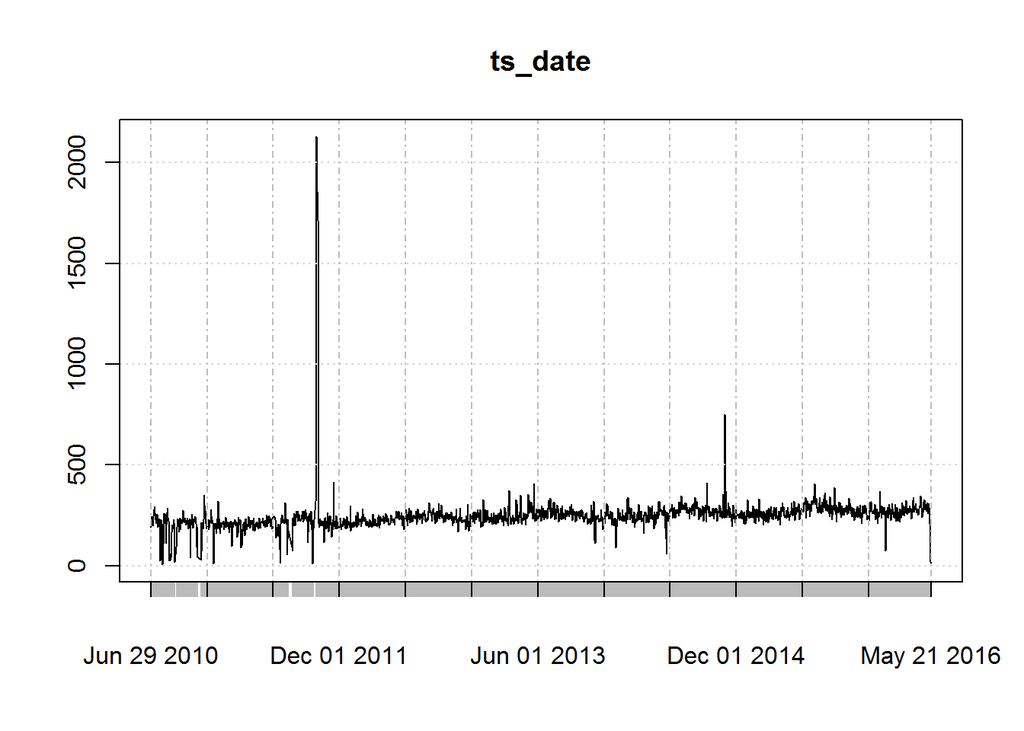

```r
ts_date <- xts(calls911_date$n, order.by = calls911_date$date)

plot(ts_date)
```

Investigate the large spike in volume.

```r
arrange(calls911_date, desc(n))
```

```
## Source: local data frame [2,108 x 2]
##
##          date     n
##        <date> <int>
## 1  2011-09-29  2128
## 2  2011-09-30  1867
## 3  2011-10-01  1857
## 4  2011-10-02  1829
## 5  2011-10-03  1715
## 6  2011-10-04   872
## 7  2014-10-30   749
## 8  2011-11-15   415
## 9  2014-09-11   411
## 10 2015-07-05   408
## ..        ...   ...
```

Based on the intial daily inspection, the data looks unstable until November 2011. As well, the latest week looks uncured. Moving forward, these dates should be excluded to avoid training on noise.

Now inspect the number of distinct days in each month with log entries to ensure we only select from stable months.

```r
dcast(calls911_month, year ~ month, value.var = 'days')
```

```
##   year  1  2  3  4  5  6  7  8  9 10 11 12
## 1 2010 NA NA NA NA NA  2 31 29 26 31 20 31
## 2 2011 31 28 29 30 31 24 20 31 23 31 30 31
## 3 2012 31 29 31 30 31 30 31 31 30 31 30 31
## 4 2013 31 28 31 30 31 30 31 31 30 31 27 31
## 5 2014 31 28 31 30 30 30 31 31 30 31 30 31
## 6 2015 31 28 31 30 31 30 31 31 30 31 30 31
## 7 2016 31 29 31 30 21 NA NA NA NA NA NA NA
```

It appears that time series is not represented consistently until October 2011. Hence, the time filter determined earlier is still valid.

Now create a time series at the monthly aggregation level.

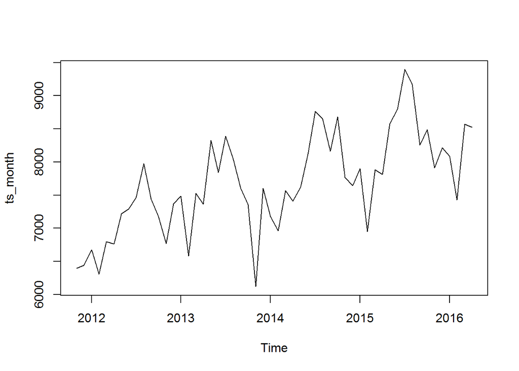

```r
df <- filter(calls911_month, date >= '2011-11-01' & date <= '2016-04-01')

ts_month <- ts(df$count, start = (2011 + (11 - 1)/12), deltat = 1/12)

plot(ts_month)
```

### Investigating monthly Fire 911 call dispatch volumes

The initial look appeared that there was a significant growth trend and likely heterogenity is present. Now compare plots with different transformations (none, log, and differenced logs).

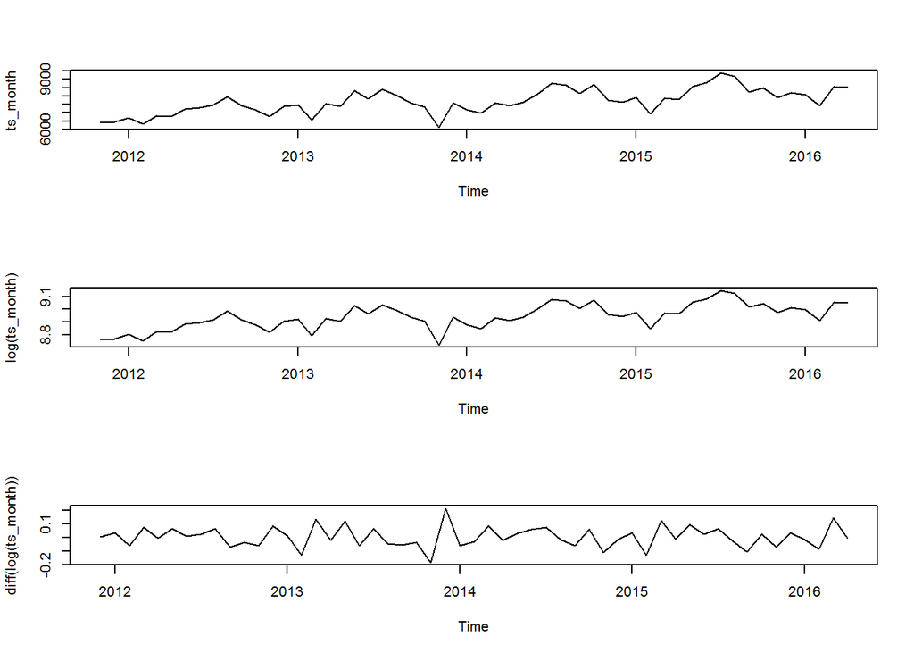

```r
par(mfrow=c(3,1))
plot(ts_month)
plot(log(ts_month))
plot(diff(log(ts_month)))
```

```r
par(mfrow=c(1,1))
```

Now lets also look at the ACF & PACF plots to investigate autocorrelation patterns for different ransformations (none, log, and differenced logs).

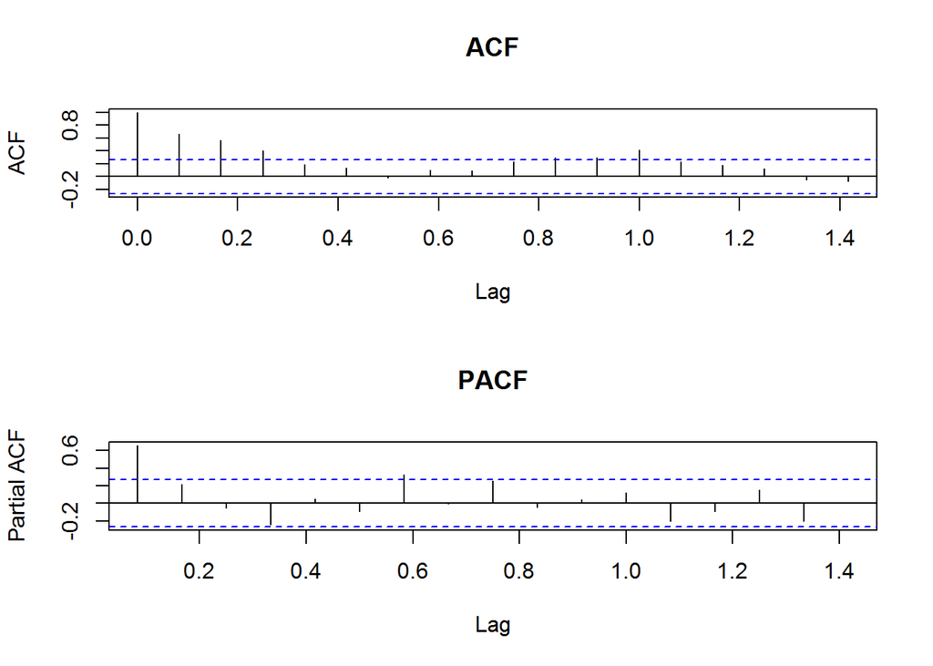

```r
# plot acf & pacf function
acf_plots <- function(ts) {
  par(mfrow=c(2,1))
  acf(ts, main = "ACF")
  pacf(ts, main = "PACF")
  par(mfrow=c(1,1))
}

# plot for all transformations
acf_plots(ts_month)
```

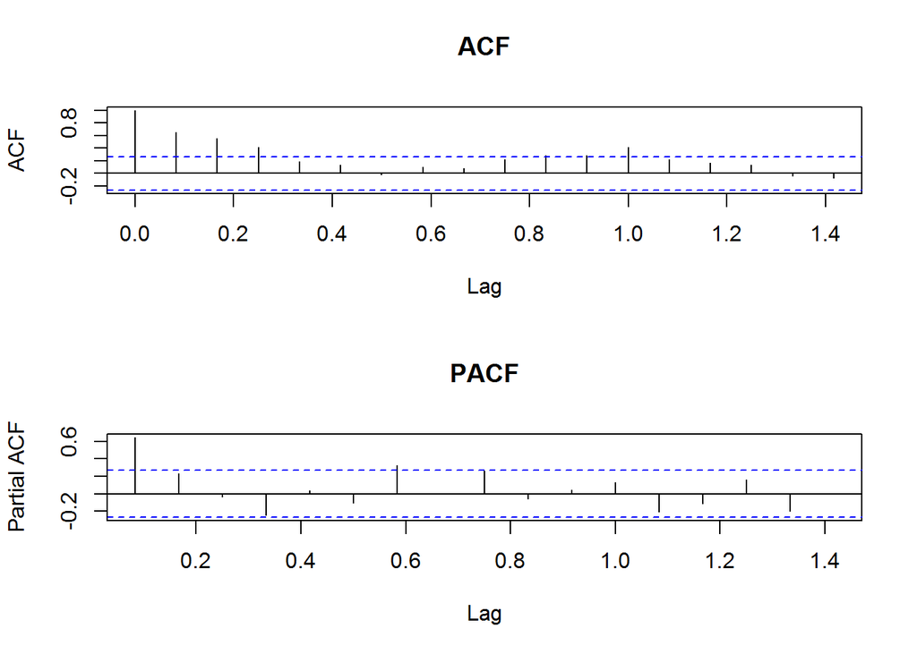

```r
acf_plots(log(ts_month))
```

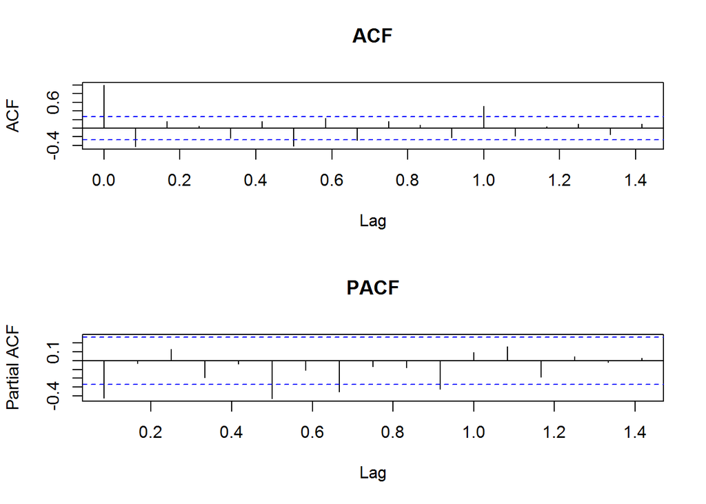

```r
acf_plots(diff(log(ts_month)))
```

Looking at the ACF and PACF plots we see the presence of trend and seasonal correlations. Differencing the logged series controls for many of these correlations.

Overall, it looks like the series as will need to be log transformed to control for heterogenity. Further, differencing will be required; however, no transform is required for this as the `d` variable in ARIMA(p, d, q) accounts for this.

Now lets use the Adjusted Dickey-Fuller test for stationarity to evaluate if the series is stationary.

```r
# use log
ts_month_log <- log(ts_month)

# test for stationarity
adf.test(diff(ts_month_log), alternative = 'stationary')
```

```
##
##  Augmented Dickey-Fuller Test
##
## data:  diff(ts_month_log)
## Dickey-Fuller = -3.9428, Lag order = 3, p-value = 0.01873
## alternative hypothesis: stationary
```

We reject the null hypothesis of the series not being stationary.

Next lets decompose the log time series.

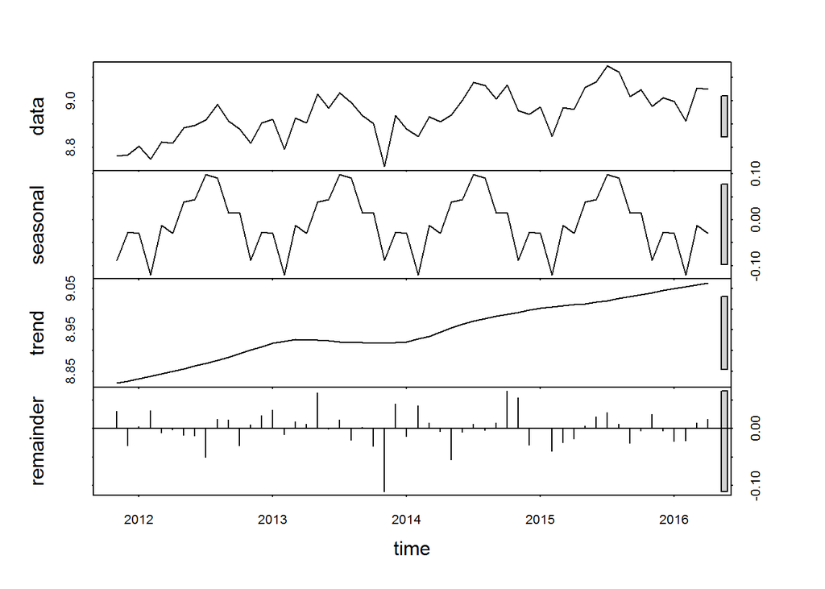

```r
# decompose
ts_decomp <- stl(ts_month_log, s.window = 'periodic')
plot(ts_decomp)
```

Clear trend and seasonal components exist. To generalize the trend in growth of the 911 calls, lets investigate using an OLS model on the trend component of the series.

```r
# run lm on the trend
trend <- ts_decomp$time.series[,2]

trend_lm <- lm(trend ~ time(trend))
summary(trend_lm)
```

```
##
## Call:
## lm(formula = trend ~ time(trend))
##
## Residuals:
##        Min         1Q     Median         3Q        Max
## -0.0238970 -0.0067004  0.0009893  0.0043110  0.0240215
##
## Coefficients:
##               Estimate Std. Error t value Pr(>|t|)
## (Intercept) -94.138130   2.399831  -39.23   <2e-16 ***
## time(trend)   0.051183   0.001192   42.95   <2e-16 ***
## ---
## Signif. codes:  0 '***' 0.001 '**' 0.01 '*' 0.05 '.' 0.1 ' ' 1
##
## Residual standard error: 0.01137 on 52 degrees of freedom
## Multiple R-squared:  0.9726, Adjusted R-squared:  0.9721
## F-statistic:  1845 on 1 and 52 DF,  p-value: < 2.2e-16
```

Note that despite the model being simple is very strong linear fit. The $R^2$ of .9726, implies that the model explains 97% of the trend data’s variance. This implies the growth rate typically follows a linear pattern. As is seen visually in the following plot.

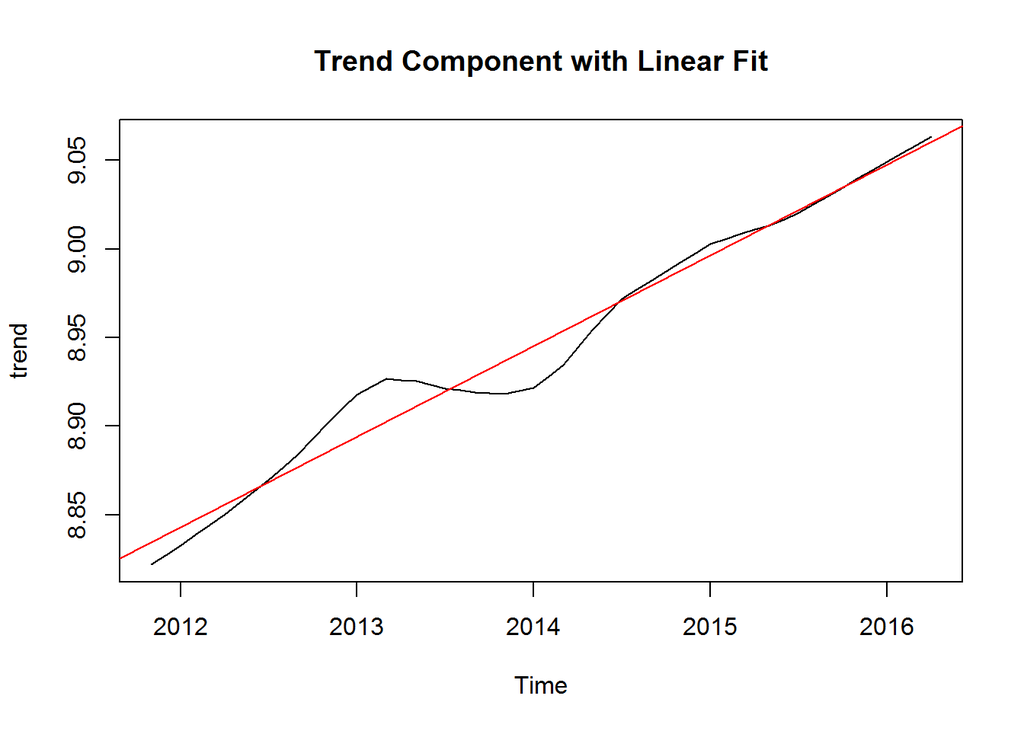

```r
# plot model
plot(trend, main = "Trend Component with Linear Fit")
abline(mC <- lm(trend ~ time(trend)), col = "red")
```

Since the trend series is logged and 1 unit of time is set to 1 year, the time coefficient represents the annual growth rate. Now calculate the growth rate by raising the coefficient by applying an exponential to remove the log.

```r
# linear trend implication
exp(trend_lm$coefficients[2])
```

```
## time(trend)
##    1.052516
```

The linear model implies that each year has an average +5.25% growth rate in monthly call volume.

### Predicting monthly Fire 911 call dispatch volumes using ARIMA

Now that the series is investigated and transformed to a stationary time series, an ARIMA model can now be fitted. The goal is to forecast out 12 months of monthly volume of Seattle Fire 911 call dispatches.

To do this use `auto.arima` to find the model with the parameters of best fit.

```r
# use auto.arima to fit the model
fit_arima <- auto.arima(ts_month_log,
          max.p=5, max.q=5, max.d=2,
          max.P=2, max.Q=2, max.D=2,
          max.order=8,
          start.p=0, start.q=0,
          start.P=0, start.Q=0,
          stepwise = FALSE)

# inspect model
summary(fit_arima)
```

```
## Series: ts_month_log
## ARIMA(1,1,0)(1,0,0)[12]
##
## Coefficients:
##           ar1    sar1
##       -0.4683  0.6036
## s.e.   0.1209  0.1037
##
## sigma^2 estimated as 0.003106:  log likelihood=76.01
## AIC=-146.02   AICc=-145.53   BIC=-140.11
##
## Training set error measures:
##                       ME       RMSE        MAE       MPE      MAPE
## Training set 0.004378475 0.05415882 0.04354092 0.0465739 0.4873238
##                   MASE       ACF1
## Training set 0.6568254 -0.0148687
```

Using `auto.arima`, an ARIMA(1,1,0)(1,0,0) process is determined to have the best fit. As previously noted, the ARIMA model accounted for differencing. Moreover, both the model processes are auto-regressive.

Now evaluate the fit by looking at the residuals. First look at the residuals over time.

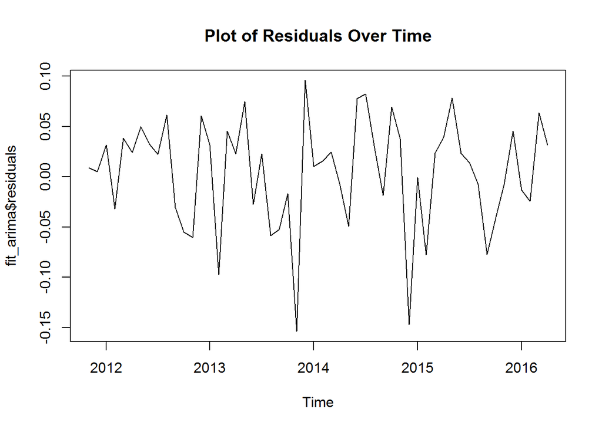

```r
plot(fit_arima$residuals, main = "Plot of Residuals Over Time")
```

No noticable consistent time dependent patterns. Now check normality of residuals.

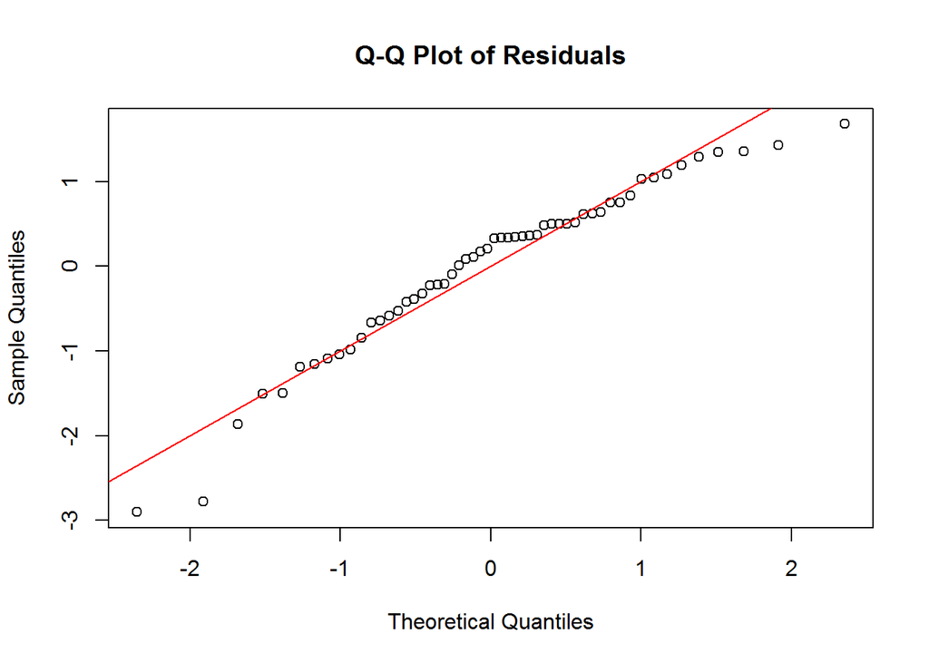

```r
qqnorm(scale(fit_arima$residuals), main = "Q-Q Plot of Residuals")
abline(a = 0, b = 1, col = 'red')
```

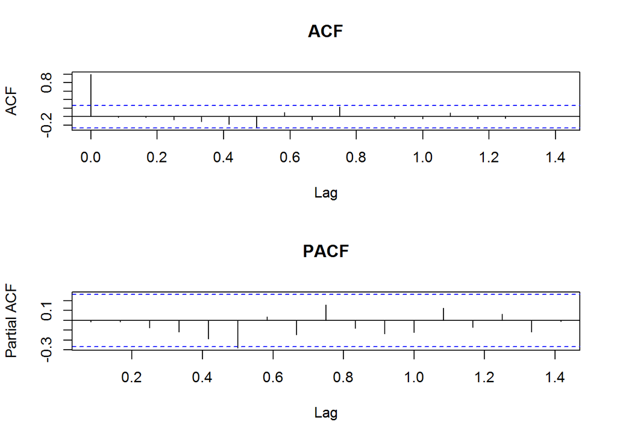

```r
acf_plots(fit_arima$residuals)
```

Plots inidicate that there are no significant autocorrelations in the residuals. At this point the ARIMA model is looking good and not violating assumptions.

Lets evaluate how the fitted values compare to actuals and calculate the MAPE.

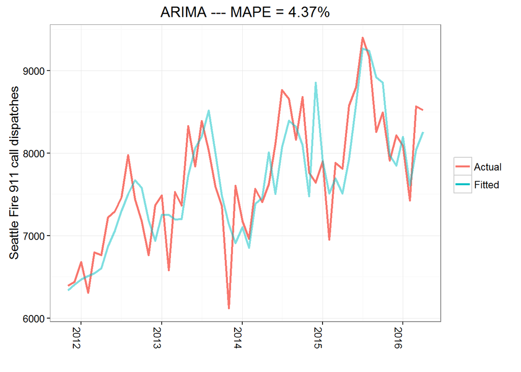

```r
### MAPE (mean absolute percentage error)
df <- data.frame(exp(fit_arima$fitted), #fitted values
                 ts_month,             #actual values
                 as.Date(time(ts_month)))
colnames(df) <- c("Fitted", "Actual", "Date")

MAPE <- df %>% summarise(MAPE=mean(abs(Actual-Fitted)/Actual))

### Plot actual versus predicted
ggplot(data=df, aes(x=Date)) +
  geom_line(aes(y=Actual, colour = "Actual"), size=1) +
  geom_line(aes(y=Fitted, colour = "Fitted"), size=1, alpha=.5) +
  theme_bw() + theme(legend.title = element_blank()) +
  ylab("Seattle Fire 911 call dispatches") + xlab("") +
  ggtitle(paste0("ARIMA --- MAPE = ", round(100*MAPE,2), "%")) +
  theme(axis.text.x=element_text(angle = -90, hjust = 0))
```

Now predict future monthly call dispatches for the next 12 months.

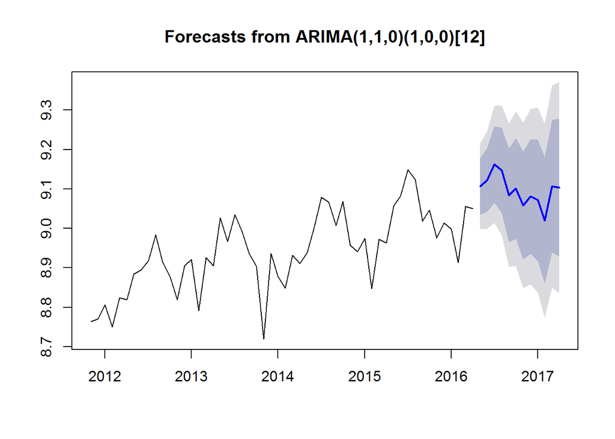

```r
pred_arima <- forecast(fit_arima, h = 12)

plot(pred_arima)
```

Note that values are still in logs.

Finally convert from the predicted log values to produce the final predicted monthly volume counts of Seattle Fire 911 call dispatches.

```r
# show actual values
round(exp(pred_arima$mean), digits = 0)
```

```
##       Jan  Feb  Mar  Apr  May  Jun  Jul  Aug  Sep  Oct  Nov  Dec
## 2016                     9017 9156 9529 9390 8814 8964 8589 8786
## 2017 8704 8268 9013 8984
```

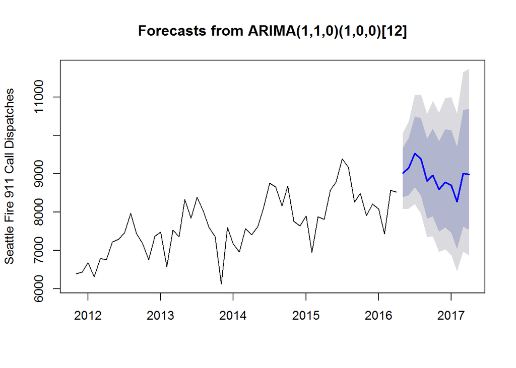

```r
# convert predicted values
pred_arima$lower <- exp(pred_arima$lower)
pred_arima$upper <- exp(pred_arima$upper)
pred_arima$mean <- exp(pred_arima$mean)
pred_arima$x <- exp(pred_arima$x)

# plot
plot(pred_arima, ylab = "Seattle Fire 911 Call Dispatches")
```